# Lesson 05

## Peruvian blood pressure

Load the peru data. Calculate FracLife variable. Fit full multiple linear regression model of Systol on nine predictors. Fit reduced multiple linear regression model of Systol on four predictors. Calculate SSE for the full and reduced models. Calculate the general linear F statistic by hand and find the p-value. Use the anova function with full and reduced models to display F-statistic and p-value directly.

```r
peru <- read.table("./Data/peru.txt", header=T)
attach(peru)

FracLife <- Years/Age

model.1 <- lm(Systol ~ Age + Years + FracLife + Weight + Height + Chin +
              Forearm + Calf + Pulse)
summary(model.1)
```

```
##
## Call:
## lm(formula = Systol ~ Age + Years + FracLife + Weight + Height +
##     Chin + Forearm + Calf + Pulse)
##
## Residuals:
##      Min       1Q   Median       3Q      Max
## -12.3442  -6.3972   0.0507   5.7292  14.5257
##
## Coefficients:
##               Estimate Std. Error t value Pr(>|t|)
## (Intercept)  146.81907   48.97096   2.998 0.005526 **
## Age           -1.12144    0.32741  -3.425 0.001855 **
## Years          2.45538    0.81458   3.014 0.005306 **
## FracLife    -115.29395   30.16900  -3.822 0.000648 ***
## Weight         1.41393    0.43097   3.281 0.002697 **
## Height        -0.03464    0.03686  -0.940 0.355194
## Chin          -0.94369    0.74097  -1.274 0.212923
## Forearm       -1.17085    1.19329  -0.981 0.334612
## Calf          -0.15867    0.53716  -0.295 0.769810
## Pulse          0.11455    0.17043   0.672 0.506818
## ---
## Signif. codes:  0 '***' 0.001 '**' 0.01 '*' 0.05 '.' 0.1 ' ' 1
##
## Residual standard error: 8.655 on 29 degrees of freedom
## Multiple R-squared:  0.6674, Adjusted R-squared:  0.5641
## F-statistic: 6.465 on 9 and 29 DF,  p-value: 5.241e-05
```

```r
#               Estimate Std. Error t value Pr(>|t|)
# (Intercept)  146.81907   48.97096   2.998 0.005526 **
# Age           -1.12144    0.32741  -3.425 0.001855 **
# Years          2.45538    0.81458   3.014 0.005306 **
# FracLife    -115.29395   30.16900  -3.822 0.000648 ***
# Weight         1.41393    0.43097   3.281 0.002697 **
# Height        -0.03464    0.03686  -0.940 0.355194
# Chin          -0.94369    0.74097  -1.274 0.212923
# Forearm       -1.17085    1.19329  -0.981 0.334612
# Calf          -0.15867    0.53716  -0.295 0.769810
# Pulse          0.11455    0.17043   0.672 0.506818

anova(model.1)
```

```
## Analysis of Variance Table
##
## Response: Systol
##           Df  Sum Sq Mean Sq F value    Pr(>F)
## Age        1    0.22    0.22  0.0030  0.956852
## Years      1   82.55   82.55  1.1019  0.302514
## FracLife   1 3112.41 3112.41 41.5449 4.728e-07 ***
## Weight     1  706.54  706.54  9.4311  0.004603 **
## Height     1    1.68    1.68  0.0224  0.882117
## Chin       1  297.68  297.68  3.9735  0.055704 .
## Forearm    1  113.91  113.91  1.5205  0.227440
## Calf       1   10.01   10.01  0.1336  0.717420
## Pulse      1   33.84   33.84  0.4518  0.506818
## Residuals 29 2172.58   74.92
## ---
## Signif. codes:  0 '***' 0.001 '**' 0.01 '*' 0.05 '.' 0.1 ' ' 1
```

```r
#           Df  Sum Sq Mean Sq F value    Pr(>F)
# Age        1    0.22    0.22  0.0030  0.956852
# Years      1   82.55   82.55  1.1019  0.302514
# FracLife   1 3112.41 3112.41 41.5449 4.728e-07 ***
# Weight     1  706.54  706.54  9.4311  0.004603 **
# Height     1    1.68    1.68  0.0224  0.882117
# Chin       1  297.68  297.68  3.9735  0.055704 .
# Forearm    1  113.91  113.91  1.5205  0.227440
# Calf       1   10.01   10.01  0.1336  0.717420
# Pulse      1   33.84   33.84  0.4518  0.506818
# Residuals 29 2172.58   74.92

model.2 <- lm(Systol ~ Age + Years + FracLife + Weight)
summary(model.2)
```

```
##
## Call:
## lm(formula = Systol ~ Age + Years + FracLife + Weight)
##
## Residuals:
##     Min      1Q  Median      3Q     Max
## -16.890  -5.976   0.058   5.407  16.835
##
## Coefficients:
##              Estimate Std. Error t value Pr(>|t|)
## (Intercept)  116.8354    21.9797   5.316 6.69e-06 ***
## Age           -0.9507     0.3164  -3.004 0.004971 **
## Years          2.3393     0.7714   3.032 0.004621 **
## FracLife    -108.0728    28.3302  -3.815 0.000549 ***
## Weight         0.8324     0.2754   3.022 0.004742 **
## ---
## Signif. codes:  0 '***' 0.001 '**' 0.01 '*' 0.05 '.' 0.1 ' ' 1
##
## Residual standard error: 8.795 on 34 degrees of freedom
## Multiple R-squared:  0.5974, Adjusted R-squared:   0.55
## F-statistic: 12.61 on 4 and 34 DF,  p-value: 2.142e-06
```

```r
#              Estimate Std. Error t value Pr(>|t|)
# (Intercept)  116.8354    21.9797   5.316 6.69e-06 ***
# Age           -0.9507     0.3164  -3.004 0.004971 **
# Years          2.3393     0.7714   3.032 0.004621 **
# FracLife    -108.0728    28.3302  -3.815 0.000549 ***
# Weight         0.8324     0.2754   3.022 0.004742 **

anova(model.2)
```

```
## Analysis of Variance Table
##
## Response: Systol
##           Df  Sum Sq Mean Sq F value    Pr(>F)
## Age        1    0.22    0.22  0.0029  0.957480
## Years      1   82.55   82.55  1.0673  0.308840
## FracLife   1 3112.41 3112.41 40.2409 3.094e-07 ***
## Weight     1  706.54  706.54  9.1350  0.004742 **
## Residuals 34 2629.71   77.34
## ---
## Signif. codes:  0 '***' 0.001 '**' 0.01 '*' 0.05 '.' 0.1 ' ' 1
```

```r
#           Df  Sum Sq Mean Sq F value    Pr(>F)
# Age        1    0.22    0.22  0.0029  0.957480
# Years      1   82.55   82.55  1.0673  0.308840
# FracLife   1 3112.41 3112.41 40.2409 3.094e-07 ***
# Weight     1  706.54  706.54  9.1350  0.004742 **
# Residuals 34 2629.71   77.34

(2629.71-2172.58)/(34-29) / (2172.58/29) # F = 1.220371
```

```
## [1] 1.220371
```

```r
pf(1.220371, 5, 29, lower.tail=F) # p-value = 0.3247213
```

```
## [1] 0.3247213
```

```r
anova(model.2, model.1)
```

```
## Analysis of Variance Table
##
## Model 1: Systol ~ Age + Years + FracLife + Weight
## Model 2: Systol ~ Age + Years + FracLife + Weight + Height + Chin + Forearm +
##     Calf + Pulse
##   Res.Df    RSS Df Sum of Sq      F Pr(>F)
## 1     34 2629.7
## 2     29 2172.6  5    457.12 1.2204 0.3247
```

```r
#   Res.Df    RSS Df Sum of Sq      F Pr(>F)
# 1     34 2629.7
# 2     29 2172.6  5    457.12 1.2204 0.3247

detach(peru)
```

## Measurements of college students

Load the Physical data. Fit full multiple linear regression model of Height on LeftArm, LeftFoot, HeadCirc, and nose. Create a residual plot. Fit reduced multiple linear regression model of Height on LeftArm and LeftFoot. Calculate SSE for the full and reduced models. Calculate the general linear F statistic by hand and find the p-value. Use the anova function with full and reduced models to display F-statistic and p-value directly. Calculate partial R-squared for (LeftArm | LeftFoot).

```r
physical <- read.table("./Data/Physical.txt", header=T)
attach(physical)

model.1 <- lm(Height ~ LeftArm + LeftFoot + HeadCirc + nose)
summary(model.1)
```

```
##
## Call:
## lm(formula = Height ~ LeftArm + LeftFoot + HeadCirc + nose)
##
## Residuals:
##     Min      1Q  Median      3Q     Max
## -4.0660 -1.1850 -0.1569  1.2539  5.5071
##
## Coefficients:
##             Estimate Std. Error t value Pr(>|t|)
## (Intercept) 18.50265    7.83031   2.363   0.0221 *
## LeftArm      0.80205    0.17074   4.697 2.09e-05 ***
## LeftFoot     0.99730    0.16230   6.145 1.30e-07 ***
## HeadCirc     0.08052    0.14952   0.539   0.5926
## nose        -0.14740    0.49233  -0.299   0.7659
## ---
## Signif. codes:  0 '***' 0.001 '**' 0.01 '*' 0.05 '.' 0.1 ' ' 1
##
## Residual standard error: 2.183 on 50 degrees of freedom
## Multiple R-squared:  0.774,  Adjusted R-squared:  0.7559
## F-statistic: 42.81 on 4 and 50 DF,  p-value: 1.447e-15
```

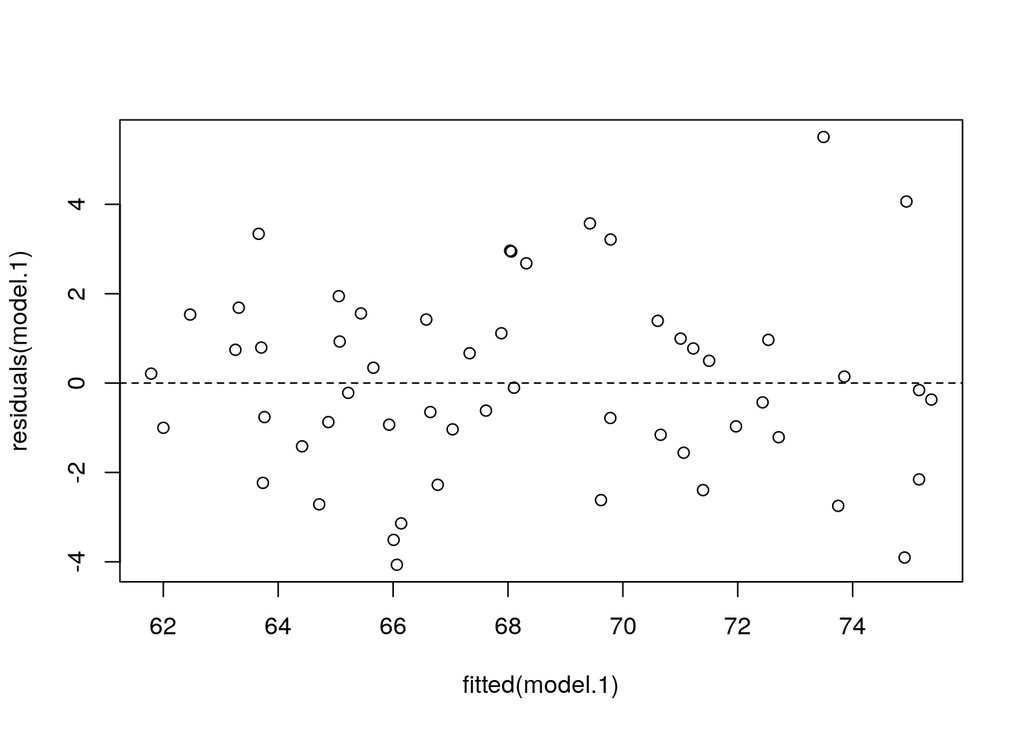

```r
#             Estimate Std. Error t value Pr(>|t|)
# (Intercept) 18.50265    7.83031   2.363   0.0221 *
# LeftArm      0.80205    0.17074   4.697 2.09e-05 ***
# LeftFoot     0.99730    0.16230   6.145 1.30e-07 ***
# HeadCirc     0.08052    0.14952   0.539   0.5926
# nose        -0.14740    0.49233  -0.299   0.7659

plot(fitted(model.1), residuals(model.1),
     panel.last = abline(h=0, lty=2))
```

```r
anova(model.1)
```

```
## Analysis of Variance Table
##
## Response: Height
##           Df Sum Sq Mean Sq  F value    Pr(>F)
## LeftArm    1 590.21  590.21 123.8106 3.917e-15 ***
## LeftFoot   1 224.35  224.35  47.0621 9.931e-09 ***
## HeadCirc   1   1.40    1.40   0.2940    0.5901
## nose       1   0.43    0.43   0.0896    0.7659
## Residuals 50 238.35    4.77
## ---
## Signif. codes:  0 '***' 0.001 '**' 0.01 '*' 0.05 '.' 0.1 ' ' 1
```

```r
#           Df Sum Sq Mean Sq  F value    Pr(>F)
# LeftArm    1 590.21  590.21 123.8106 3.917e-15 ***
# LeftFoot   1 224.35  224.35  47.0621 9.931e-09 ***
# HeadCirc   1   1.40    1.40   0.2940    0.5901
# nose       1   0.43    0.43   0.0896    0.7659
# Residuals 50 238.35    4.77

model.2 <- lm(Height ~ LeftArm + LeftFoot)
summary(model.2)
```

```
##
## Call:
## lm(formula = Height ~ LeftArm + LeftFoot)
##
## Residuals:
##    Min     1Q Median     3Q    Max
## -4.075 -1.179 -0.099  1.248  5.196
##
## Coefficients:
##             Estimate Std. Error t value Pr(>|t|)
## (Intercept)  21.8572     3.5840   6.098 1.35e-07 ***
## LeftArm       0.7958     0.1652   4.816 1.31e-05 ***
## LeftFoot      1.0229     0.1468   6.969 5.54e-09 ***
## ---
## Signif. codes:  0 '***' 0.001 '**' 0.01 '*' 0.05 '.' 0.1 ' ' 1
##
## Residual standard error: 2.149 on 52 degrees of freedom
## Multiple R-squared:  0.7723, Adjusted R-squared:  0.7635
## F-statistic: 88.18 on 2 and 52 DF,  p-value: < 2.2e-16
```

```r
#             Estimate Std. Error t value Pr(>|t|)
# (Intercept)  21.8572     3.5840   6.098 1.35e-07 ***
# LeftArm       0.7958     0.1652   4.816 1.31e-05 ***
# LeftFoot      1.0229     0.1468   6.969 5.54e-09 ***

anova(model.2)
```

```
## Analysis of Variance Table
##
## Response: Height
##           Df Sum Sq Mean Sq F value    Pr(>F)
## LeftArm    1 590.21  590.21 127.782 1.275e-15 ***
## LeftFoot   1 224.35  224.35  48.572 5.538e-09 ***
## Residuals 52 240.18    4.62
## ---
## Signif. codes:  0 '***' 0.001 '**' 0.01 '*' 0.05 '.' 0.1 ' ' 1
```

```r
#           Df Sum Sq Mean Sq F value    Pr(>F)
# LeftArm    1 590.21  590.21 127.782 1.275e-15 ***
# LeftFoot   1 224.35  224.35  48.572 5.538e-09 ***
# Residuals 52 240.18    4.62

(240.18-238.35)/(52-50) / (238.35/50) # F = 0.1919446
```

```
## [1] 0.1919446
```

```r
pf(0.1919446, 2, 50, lower.tail=F) # p-value = 0.8259579
```

```
## [1] 0.8259579
```

```r
anova(model.2, model.1)
```

```
## Analysis of Variance Table
##
## Model 1: Height ~ LeftArm + LeftFoot
## Model 2: Height ~ LeftArm + LeftFoot + HeadCirc + nose
##   Res.Df    RSS Df Sum of Sq      F Pr(>F)
## 1     52 240.18
## 2     50 238.35  2    1.8289 0.1918 0.8261
```

```r
#   Res.Df    RSS Df Sum of Sq      F Pr(>F)
# 1     52 240.18
# 2     50 238.35  2    1.8289 0.1918 0.8261

model.3 <- lm(Height ~ LeftFoot)
anova(model.3)
```

```
## Analysis of Variance Table
##
## Response: Height
##           Df Sum Sq Mean Sq F value    Pr(>F)
## LeftFoot   1 707.42  707.42  107.95 2.172e-14 ***
## Residuals 53 347.33    6.55
## ---
## Signif. codes:  0 '***' 0.001 '**' 0.01 '*' 0.05 '.' 0.1 ' ' 1
```

```r
#           Df Sum Sq Mean Sq F value    Pr(>F)
# LeftFoot   1 707.42  707.42  107.95 2.172e-14 ***
# Residuals 53 347.33    6.55

(347.33-240.18) / 347.33 # Partial R-squared (LeftArm | LeftFoot) = 0.3084962
```

```
## [1] 0.3084962
```

```r
detach(physical)
```